# P8105_hw6_nk3037

Navya Koneripalli

2023-11-28

## Question 2

### Setup

```r
weather_df =
  rnoaa::meteo_pull_monitors(
    c("USW00094728"),
    var = c("PRCP", "TMIN", "TMAX"),
    date_min = "2022-01-01",
    date_max = "2022-12-31") |>
  mutate(
    name = recode(id, USW00094728 = "CentralPark_NY"),
    tmin = tmin / 10,
    tmax = tmax / 10) |>
  select(name, id, everything())
```

```
## using cached file: /Users/nkoneripalli/Library/Caches/org.R-project.R/R/rnoaa/noaa_ghcnd/USW00094728.dly
```

```
## date created (size, mb): 2023-11-28 16:18:33.584835 (8.544)
```

```
## file min/max dates: 1869-01-01 / 2023-11-30
```

In this model, ‘tmax’ is the response and ‘tmin’ and ‘prcp’ are the predictors.

```r
# Initial linear model
lin_model = lm(tmax ~ tmin + prcp, data = weather_df)
```

Plotting r-square distribution using 5000 bootstrap samples

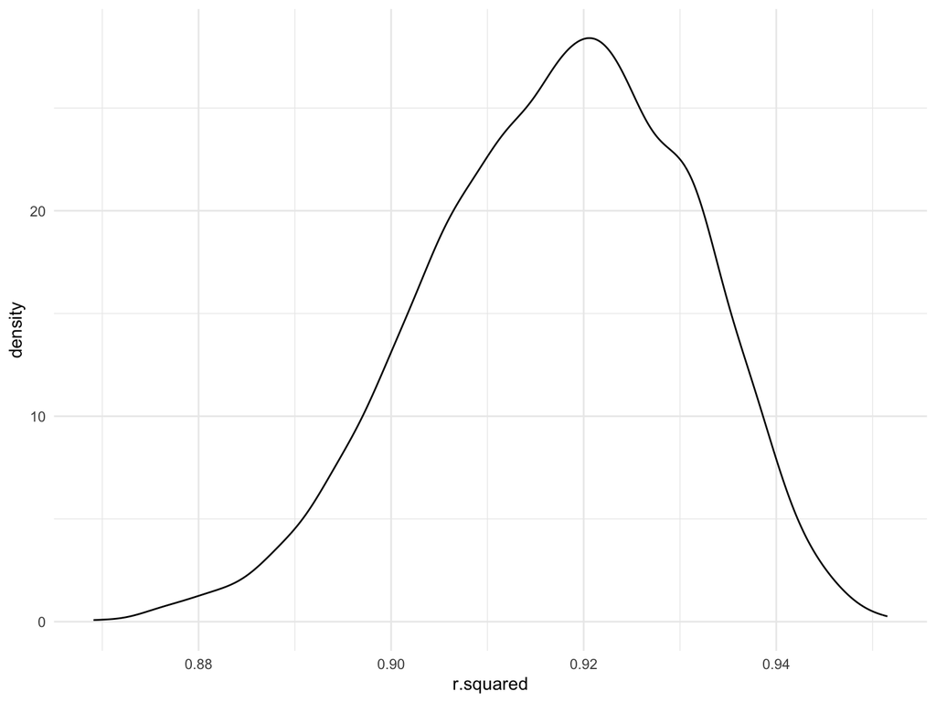

```r
# Bootstrapping
weather_rsq = weather_df %>%
    modelr::bootstrap(n = 5000, id="strap_count") %>%
    mutate(
     models = map(.x=strap, ~lm(tmax ~ tmin + prcp, data = .x)),
     results = map(.x=models, broom::glance)) %>%
    select(strap_count, results) %>%
    unnest(results)

# Plotting
weather_rsq %>%
  ggplot(aes(x = r.squared)) + geom_density()
```

```r
# Calculating CIs
weather_rsq %>%
  summarize(
    ci_lower = quantile(r.squared, 0.025),
    ci_upper = quantile(r.squared, 0.975))
```

```
## # A tibble: 1 × 2
##   ci_lower ci_upper
##      <dbl>    <dbl>
## 1    0.889    0.940
```

The distribution of r squared is skewed left. The most common r^2 value is between 0.92-0.925. The mean r^2 value is 0.92. Since the distribution is not normal, it may be safe to assume that a linear model is not the best approach for this data and instead a generalized linear model or non-parametric methods may be better.

Plotting log(b1*b2) distribution using 5000 bootstrap samples

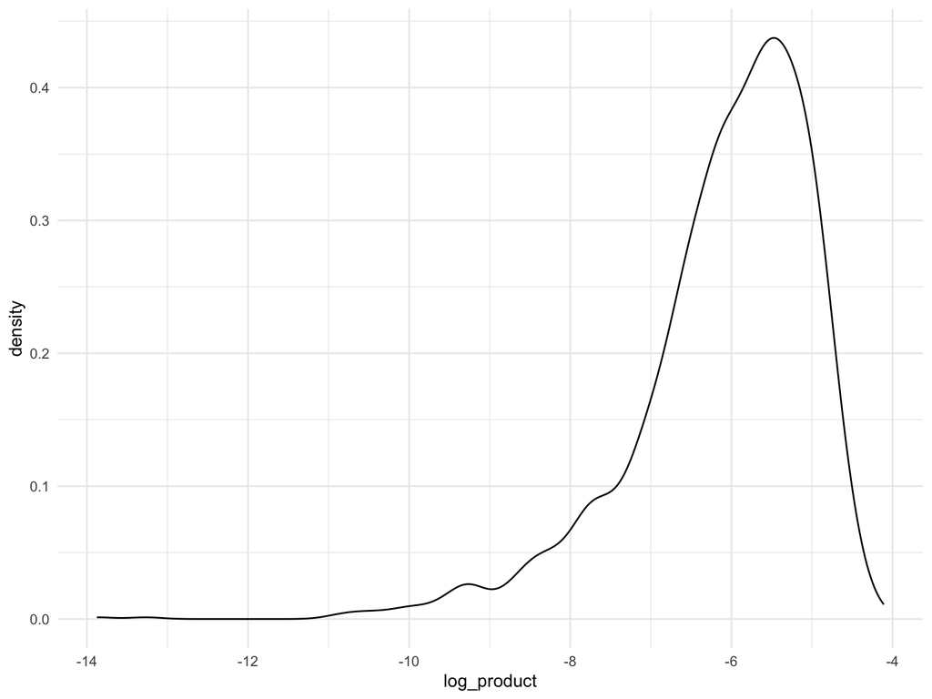

```r
# Bootstrapping
weather_logb = weather_df %>%
    modelr::bootstrap(n = 5000, id="strap_number") %>%
     mutate(
      models = map(.x=strap, ~lm(tmax ~ tmin + prcp, data = .x)),
      results = map(models, broom::tidy)) %>%
    select(strap_number, results) %>%
    unnest(results) %>%
    pivot_wider(
      names_from = term,
      values_from = estimate) %>%
    group_by(strap_number) %>%
    summarize(
     tmin = first(na.omit(tmin)),
     prcp = first(na.omit(prcp)),
     log_product = log(tmin * prcp)
    )

# Plotting
weather_logb %>%
  filter(log_product!="NaN") %>%
  ggplot(aes(x=log_product))+geom_density()
```

```r
# Calculating CIs
log_product_conf_int =weather_logb |>
  summarize(
    lower_ci = quantile(log_product, 0.025, na.rm=TRUE),
    upper_ci = quantile(log_product, 0.975,na.rm=TRUE)
  )
```

The distribution of the log product is left-skewed with the curve peaking at around -5.5 on a graph of range -13 to -4. The 95% confidence interval is (-8.947,-4.571).

## Question 3

```r
# Loading the birth weight data
birthweight = read_csv("./data/birthweight.csv")
# Data cleaning
birthweight = janitor::clean_names(birthweight, case = "snake")%>%
  mutate(
    babysex = factor(babysex),
    frace = factor(frace, levels = c(1, 2, 3, 4, 8, 9)),
    mrace = factor(mrace, levels = c(1, 2, 3, 4, 8)),
    malform = factor(malform),
    smoken = factor(smoken),
    parity = factor(parity)
  ) %>%
  na.omit(birthweight)

# Regression model
model1 = lm (bwt ~ mheight + delwt, data = birthweight)
summary(model1)
```

```
##
## Call:
## lm(formula = bwt ~ mheight + delwt, data = birthweight)
##
## Residuals:
##      Min       1Q   Median       3Q      Max
## -2428.44  -282.55    23.91   318.45  1694.15
##
## Coefficients:
##              Estimate Std. Error t value Pr(>|t|)
## (Intercept) 1183.6818   179.4773   6.595 4.76e-11 ***
## mheight       17.1170     3.0640   5.586 2.46e-08 ***
## delwt          5.7972     0.3665  15.817  < 2e-16 ***
## ---
## Signif. codes:  0 '***' 0.001 '**' 0.01 '*' 0.05 '.' 0.1 ' ' 1
##
## Residual standard error: 488.8 on 4339 degrees of freedom
## Multiple R-squared:  0.08943,    Adjusted R-squared:  0.08901
## F-statistic: 213.1 on 2 and 4339 DF,  p-value: < 2.2e-16
```

The simple linear model examines the effect that mother’s height and weight have on birth weight. I think the mother’s weight and height are the most accurate predictors for the baby’s weight. I think these variables are stronger predictors than income or race/ethnicity, and than the biological determinants of health have a greater impact on birth weight than the environmental and social determinants.

### Model residuals vs fitted values

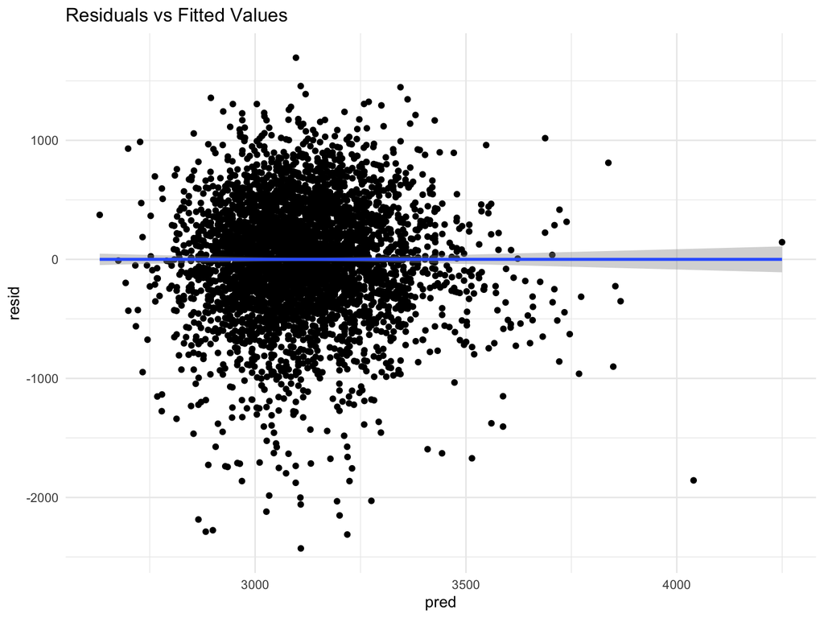

```r
birthweight %>%
  add_predictions(model1)  %>%
  add_residuals(model1)  %>%
  ggplot(aes(x = pred, y = resid)) +  geom_point() +
  geom_smooth(method = "lm") +
  labs(
    title = "Residuals vs Fitted Values ")
```

### Comparing to the other two models

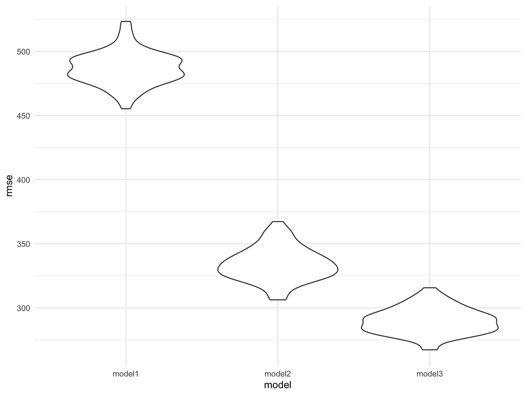

```r
model2 = lm(bwt ~ blength + gaweeks, data = birthweight)
model3 = lm(bwt ~ bhead * blength * babysex, data = birthweight)

cv_df =
  crossv_mc(birthweight, 100)  # 100 cross validation runs

cv_df =
  cv_df %>%
  mutate(
    model1  = map(.x = train, ~lm(bwt~mheight + delwt, data = .x)),
    model2  = map(.x = train, ~lm(bwt~blength+gaweeks, data = .x)),
    model3  = map(.x = train, ~lm(bwt~bhead*blength + bhead*babysex + blength*babysex, data = .x)))  %>%
  mutate(
    rmse_model1= map2_dbl(.x=model1, .y=test, ~rmse(model = .x, data = .y)),
    rmse_model2= map2_dbl(.x=model2, .y=test, ~rmse(model = .x, data = .y)),
    rmse_model3 = map2_dbl(.x=model3, .y=test, ~rmse(model = .x, data = .y))
  )

cv_df %>%
  select(starts_with("rmse")) %>%
  pivot_longer(
    everything(),
    names_to = "model",
    values_to = "rmse",
    names_prefix = "rmse_") %>%
  mutate(
    model = fct_inorder(model)) %>%
  ggplot(aes(x = model, y = rmse)) + geom_violin()
```